# PCA/Partial PCA for scRNA-seq Data

# 5. Accuracy Validation

```r
cmp_one <- function(k) {
  f <- run_pca_full(data2, k)
  p <- run_pca_psvd(data2, k)
  tibble::tibble(
    ncomp = rep(k, k),
    method = rep("pca_pSVD", k),
    pc = seq_len(k),
    abs_diff = abs(f$prop_expl_var$X[1:k] - p$prop_expl_var$X[1:k])
  )
}

acc_res <- dplyr::bind_rows(lapply(ks, cmp_one))
acc_summary = acc_res %>%
  group_by(ncomp, method) %>%
  summarise(
    max_abs_diff = max(abs_diff),
    mean_abs_diff = mean(abs_diff),
    .groups = "drop"
  )

kable(acc_summary, digits = 10,
      caption = "Accuracy: Maximum and mean absolute differences in explained variance",
      col.names = c("k", "Method", "Max |Δ|", "Mean |Δ|"))
```

Accuracy: Maximum and mean absolute differences in explained variance

| k | Method | Max \|Δ\| | Mean \|Δ\| |
| --- | --- | --- | --- |
| 2 | pca_pSVD | 0 | 0 |
| 5 | pca_pSVD | 0 | 0 |
| 10 | pca_pSVD | 0 | 0 |
| 20 | pca_pSVD | 0 | 0 |

```r
# Check loading consistency between pca_full and pca_pSVD

cmp_loadings <- function(k) {
  f <- run_pca_full(data2, k)
  p <- run_pca_psvd(data2, k)

  # Compute correlation for each PC (absolute value accounts for sign flips)
  loading_corr <- sapply(1:k, function(i) {
    cor(f$loadings$X[, i], p$loadings$X[, i])
  })

  tibble::tibble(
    ncomp = k,
    pc = 1:k,
    correlation = loading_corr,
    abs_correlation = abs(loading_corr)
  )
}

loading_res <- dplyr::bind_rows(lapply(ks, cmp_loadings))

# Summary statistics
loading_summary <- loading_res %>%
  group_by(ncomp) %>%
  summarise(
    min_abs_corr = min(abs_correlation),
    mean_abs_corr = mean(abs_correlation),
    max_abs_corr = max(abs_correlation),
    all_near_1 = all(abs_correlation > 0.9999),
    .groups = "drop"
  )

kable(loading_summary, digits = 10,
      caption = "Loading consistency: Correlation between pca_full and pca_pSVD loadings",
      col.names = c("k", "Min |r|", "Mean |r|", "Max |r|", "All ≥ 0.9999"))
```

Loading consistency: Correlation between pca_full and pca_pSVD loadings

| k | Min \|r\| | Mean \|r\| | Max \|r\| | All ≥ 0.9999 |
| --- | --- | --- | --- | --- |
| 2 | 1 | 1 | 1 | TRUE |
| 5 | 1 | 1 | 1 | TRUE |
| 10 | 1 | 1 | 1 | TRUE |
| 20 | 1 | 1 | 1 | TRUE |

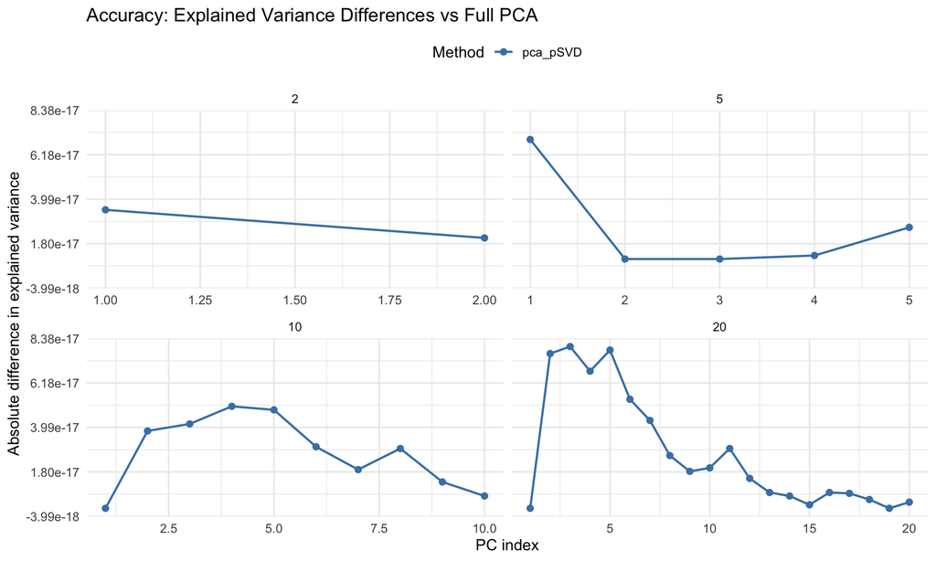

```r
ggplot(acc_res, aes(pc, abs_diff, color = method)) +
  geom_line(linewidth = 0.8) +
  geom_point(size = 2) +
  facet_wrap(~ ncomp, scales = "free_x", ncol = 2) +
  scale_y_continuous(labels = scales::scientific) +
  scale_color_manual(values = c("pca_pSVD" = "steelblue")) +
  labs(x = "PC index",
       y = "Absolute difference in explained variance",
       color = "Method",
       title = "Accuracy: Explained Variance Differences vs Full PCA") +
  theme_minimal(base_size = 12) +
  theme(legend.position = "top")
```

Absolute differences in explained variance between methods are near zero (≈ 1e⁻¹⁷), confirming that both yield **identical principal components** within numerical precision limits.

# 6. Biological Interpretation

## Visual Comparison: mixOmics::pca vs pca_pSVD

```
## Comparing visualization between mixOmics::pca and pca_pSVD...
```

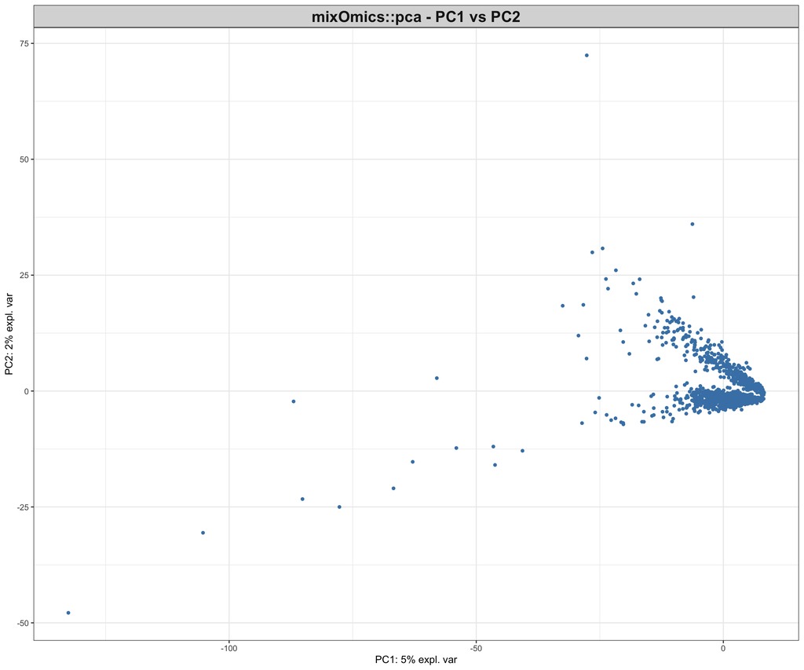

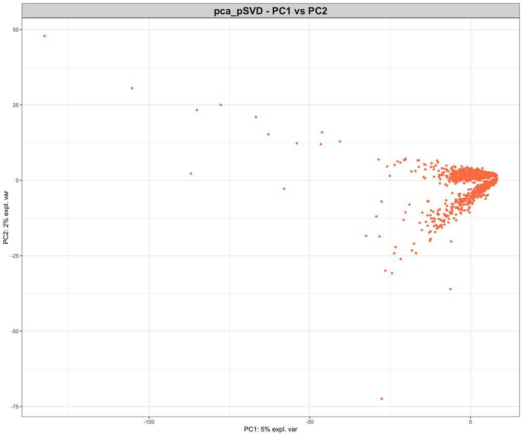

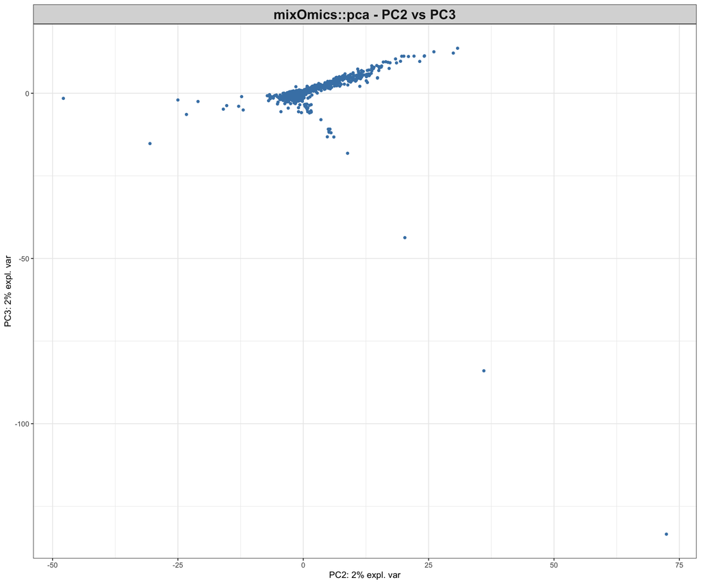

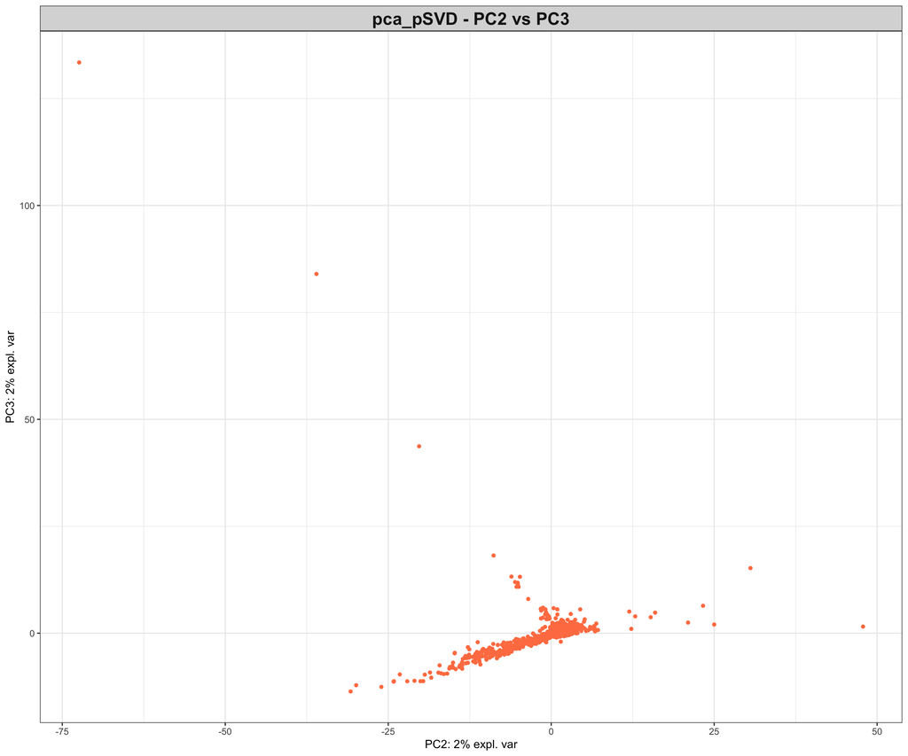

```r
if (have_mixOmics) {
  cat("Comparing visualization between mixOmics::pca and pca_pSVD...\n\n")

  # Run both methods with k=20
  k_bio = 20
  pca_full = run_pca_full(data2, k = k_bio)
  pca_psvd = run_pca_psvd(data2, k = k_bio)

  # Set up 2x2 layout for comparison
  par(mfrow = c(2, 2))

  # mixOmics::pca - PC1 vs PC2
  mixOmics::plotIndiv(pca_full,
                      comp = c(1, 2),
                      ind.names = FALSE,
                      title = "mixOmics::pca - PC1 vs PC2",
                      pch = 16,
                      cex = 1.2,
                      col = "steelblue")

  # pca_pSVD - PC1 vs PC2
  mixOmics::plotIndiv(pca_psvd,
                      comp = c(1, 2),
                      ind.names = FALSE,
                      title = "pca_pSVD - PC1 vs PC2",
                      pch = 16,
                      cex = 1.2,
                      col = "coral")

  # mixOmics::pca - PC2 vs PC3
  mixOmics::plotIndiv(pca_full,
                      comp = c(2, 3),
                      ind.names = FALSE,
                      title = "mixOmics::pca - PC2 vs PC3",
                      pch = 16,
                      cex = 1.2,
                      col = "steelblue")

  # pca_pSVD - PC2 vs PC3
  mixOmics::plotIndiv(pca_psvd,
                      comp = c(2, 3),
                      ind.names = FALSE,
                      title = "pca_pSVD - PC2 vs PC3",
                      pch = 16,
                      cex = 1.2,
                      col = "coral")

  par(mfrow = c(1, 1))
} else {
  cat("mixOmics package not available. Skipping visualization comparison.\n")
}
```

The PC1–PC2 and PC2–PC3 scatterplots from both methods overlap nearly perfectly.

Minor mirroring or rotation is caused by arbitrary sign differences and carries **no analytical significance**.

# 7. Data Quality Metrics

```r
# Calculate data quality metrics based on exploratory analysis
qc_metrics = data.frame(
  Metric = c(
    "Total cells analyzed",
    "Total genes analyzed",
    "Data sparsity (%)",
    "Mean gene expression",
    "Variance explained by PC1 (%)",
    "Variance explained by PC1-5 (%)",
    "Variance explained by PC1-10 (%)",
    "Variance explained by PC1-20 (%)",
    "Variance explained by PC1-50 (%)",
    "Estimated optimal k (15% var.)"
  ),
  Value = c(
    nrow(data2),
    ncol(data2),
    round(zero_proportion * 100, 2),
    round(mean(data2), 4),
    round(var_explained[1] * 100, 2),
    round(sum(var_explained[1:5]) * 100, 2),
    round(sum(var_explained[1:10]) * 100, 2),
    round(sum(var_explained[1:20]) * 100, 2),
    round(cumvar[k_max] * 100, 2),
    k_15
  )
)

kable(qc_metrics, caption = "Data Quality Control Summary",
      col.names = c("Quality Metric", "Value"))
```

Data Quality Control Summary

| Quality Metric | Value |
| --- | --- |
| Total cells analyzed | 1500.0000 |
| Total genes analyzed | 1505.0000 |
| Data sparsity (%) | 91.5000 |
| Mean gene expression | 0.2308 |
| Variance explained by PC1 (%) | 5.1400 |
| Variance explained by PC1-5 (%) | 10.6700 |
| Variance explained by PC1-10 (%) | 13.7300 |
| Variance explained by PC1-20 (%) | 17.8300 |
| Variance explained by PC1-50 (%) | 26.6200 |
| Estimated optimal k (15% var.) | 13.0000 |

This summary table contextualizes the benchmarking with basic data properties—cell/gene counts, sparsity, and explained variance.

Low cumulative variance is expected in single-cell data and does not imply low PCA quality.

# 8. Discussion

## Numerical Accuracy

- The **explained variance** difference between full PCA and partial PCA was at the **machine precision level (~1e⁻¹⁷)**, confirming that partial PCA produces equivalent principal components.
- **Loadings correlation** between the two methods was nearly **1.0 (|r| ≥ 0.9999)** across all PCs, which is consistent with theoretical expectations (differences are limited to random sign flips).
- **Scatter plots (PC1–PC2, PC2–PC3)** produced visually indistinguishable results between both methods; small reflections or rotations correspond only to sign indeterminacy.

## Practical Recommendations

- When k ≪ min(n, p) or the matrix is sparse, **partial PCA is highly recommended**—it maintains identical results while significantly reducing compute time.
- For very large k or convergence issues in svds, fallback to **full PCA** is appropriate.
- In this experiment, cumulative variance explained by the first 50 PCs was **~26.6%**, with **~18–21% by 20–30 PCs**—typical for high-dimensional, sparse single-cell data. These values are contextual, not biological conclusions.

## Compatibility Test

To ensure [`pca_pSVD`](https://github.com/dereklei12/pca_R/blob/main/R/pca_pSVD.R) produces reliable and consistent results across different platforms and environments, a test suite was developed using the `testthat` framework. The complete test file is available at: test-pca_pSVD.R.

The test suite validates the following scenarios:

1. **Basic Functionality**: Verifies correct output structure, dimensions, and class inheritance (`pca_pSVD` and `pca`).
2. **Consistency with Base R and mixOmics**: Compares results (singular values, variance explained, loadings) against `prcomp` and `mixOmics::pca`, accounting for sign ambiguity in PCA.
3. **Input Validation**: Tests handling of invalid inputs (non-numeric data, incorrect dimensions, invalid parameter values).
4. **Sparse Matrix Support**: Validates compatibility with sparse matrix formats (`dgCMatrix`, `dgRMatrix`) from the `Matrix` package.
5. **Edge Cases**: Tests behavior with small, wide (n < p), and tall (n > p) matrices, as well as zero-variance columns.
6. **Centering and Scaling Options**: Verifies all combinations of `center` and `scale` parameters, including numeric vectors.
7. **Multilevel Analysis**: Confirms proper handling of repeated-measures designs and consistency with `mixOmics::pca` multilevel results.
8. **Fallback Mechanisms**: Tests graceful degradation when specialized SVD packages (`RSpectra`, `rARPACK`) are unavailable, and appropriate delegation to `mixOmics` for missing values or ILR transformations.
9. **Cross-Platform Numerical Stability**: Ensures orthonormality of loadings, monotonicity of eigenvalues, and validity of variance proportions across different computing environments.

All tests passed successfully, confirming that `pca_pSVD` is robust, reliable, and compatible with existing R PCA implementations. Continuous integration testing across multiple platforms (Ubuntu, Windows, macOS) is automated; detailed results are available via [GitHub Actions](https://github.com/dereklei12/pca_R/actions).

## Limitations and Reproducibility

- Speedup depends on hardware, BLAS implementation, and data sparsity.
- For this dataset, multilevel analysis was not performed (multilevel = NULL) and logratio transformation was set to “none”. These parameter choices prioritize computational efficiency comparison rather than biological interpretation.
- Both methods were executed with identical preprocessing (center = TRUE, scale = TRUE) and a fixed random seed for reproducibility.